# NFL Combine 2000-2018

Iker Aguirre Otaegui

CUNEF, Máster en Data Science para Finanzas

30 de octubre de 2020.

### Dataset

El NFL Combine es uno de los eventos más importantes del año en el mundo del fútbol americano. En él, se invita cada año a los 335 mejores jugadores de la liga universitaria, conocidos como “prospects”, que quieran dar el salto a la liga profesional americana (NFL).

El evento consiste en la realización (optativa) de una serie de pruebas físicas. El objetivo de este evento es que los “scouts” u ojeadores de talento de los equipos puedan evaluar las aptitudes físicas de los “prospects”, para así intentar predecir cuál podría ser su desempeño futuro en el terreno de juego .

En función de la posición que el “prospect” juegue en el campo, se le dará más importancia a unas pruebas que otras (ejemplo, unos a velocidad y otros a fuerza).

Los equipos podrán elegir a los jugadores que deseen mediante el draft, otro evento posterior en el que, ordenadas de peor a mejor, las 32 franquicias de la NFL podrán elegir que “prospects” quieren que unan a sus respectivas plantillas, en un total de 7 rondas (en principio un "prospect" por ronda). Aquellos que no sean elegidos quedarán como “Undrafted”, aunque podrán ser contratados más adelante.

El objetivo de los prospects es ser elegidos lo antes posible, puesto que supone un mejor contrato. Por ello, suelen poner especial énfasis en este tipo de pruebas puesto que muchas veces puede suponer ser elegidos en una posición más alta (o baja, claro), e incluso alguna ronda antes de lo que estaba previsto.

El siguiente dataset incluye la información de todos los Combine desde el año 2000 a 2018, con información de cada jugador, resultados de sus pruebas y en qué posición fueron drafteados.

### Librerías

```python
import pandas as pd
import numpy as np
import matplotlib.pyplot as plt
import seaborn as sns
%matplotlib inline
```

## Exportación de los datos

```python
import pandas as pd
combine = pd.read_csv('combine_data.csv')
combine
```

|  | Player | Pos | Ht | Wt | Forty | Vertical | BenchReps | BroadJump | Cone | Shuttle | Year | Pfr_ID | AV | Team | Round | Pick |
| --- | --- | --- | --- | --- | --- | --- | --- | --- | --- | --- | --- | --- | --- | --- | --- | --- |
| 0 | John Abraham | OLB | 76 | 252 | 4.55 | NaN | NaN | NaN | NaN | NaN | 2000 | AbraJo00 | 26.0 | New York Jets | 1.0 | 13.0 |
| 1 | Shaun Alexander | RB | 72 | 218 | 4.58 | NaN | NaN | NaN | NaN | NaN | 2000 | AlexSh00 | 26.0 | Seattle Seahawks | 1.0 | 19.0 |
| 2 | Darnell Alford | OT | 76 | 334 | 5.56 | 25.0 | 23.0 | 94.0 | 8.48 | 4.98 | 2000 | AlfoDa20 | 0.0 | Kansas City Chiefs | 6.0 | 188.0 |
| 3 | Kyle Allamon | TE | 74 | 253 | 4.97 | 29.0 | NaN | 104.0 | 7.29 | 4.49 | 2000 | NaN | 0.0 | NaN | NaN | NaN |
| 4 | Rashard Anderson | CB | 74 | 206 | 4.55 | 34.0 | NaN | 123.0 | 7.18 | 4.15 | 2000 | AndeRa21 | 6.0 | Carolina Panthers | 1.0 | 23.0 |
| ... | ... | ... | ... | ... | ... | ... | ... | ... | ... | ... | ... | ... | ... | ... | ... | ... |
| 6213 | Chris Worley | ILB | 74 | 238 | 4.86 | 29.5 | 15.0 | NaN | NaN | NaN | 2018 | WorlCh00 | 0.0 | NaN | NaN | NaN |
| 6214 | Isaiah Wynn | G | 75 | 313 | NaN | NaN | NaN | NaN | NaN | NaN | 2018 | WynnIs00 | 0.0 | NaN | NaN | NaN |
| 6215 | Isaac Yiadom | CB | 73 | 190 | 4.52 | NaN | 8.0 | 120.0 | NaN | 4.18 | 2018 | YiadIs00 | 0.0 | NaN | NaN | NaN |
| 6216 | Kenny Young | ILB | 73 | 236 | 4.60 | 36.0 | 23.0 | 117.0 | 7.38 | 4.48 | 2018 | NaN | 0.0 | NaN | NaN | NaN |
| 6217 | Trevon Young | EDGE | 76 | 258 | 4.78 | 33.0 | 25.0 | 114.0 | 6.99 | 4.40 | 2018 | YounTr00 | 0.0 | NaN | NaN | NaN |

6218 rows × 16 columns

## Exploración preeliminar de datos en bruto

```python
list(combine)
```

```
['Player',
 'Pos',
 'Ht',
 'Wt',
 'Forty',
 'Vertical',
 'BenchReps',
 'BroadJump',
 'Cone',
 'Shuttle',
 'Year',
 'Pfr_ID',
 'AV',
 'Team',
 'Round',
 'Pick']
```

```python
combine.describe()
```

|  | Ht | Wt | Forty | Vertical | BenchReps | BroadJump | Cone | Shuttle | Year | AV | Round | Pick |
| --- | --- | --- | --- | --- | --- | --- | --- | --- | --- | --- | --- | --- |
| count | 6218.000000 | 6218.000000 | 6046.000000 | 4796.000000 | 4212.000000 | 4754.000000 | 3993.000000 | 4063.000000 | 6218.000000 | 6218.000000 | 3738.000000 | 3738.000000 |
| mean | 73.798971 | 243.372145 | 4.783784 | 32.818599 | 20.926163 | 113.943837 | 7.282307 | 4.390603 | 2009.041975 | 5.085719 | 3.838684 | 113.728464 |
| std | 2.621373 | 45.103814 | 0.305984 | 4.213729 | 6.393679 | 9.317031 | 0.422882 | 0.268836 | 5.471056 | 7.546556 | 1.952728 | 70.605155 |
| min | 65.000000 | 149.000000 | 4.220000 | 17.500000 | 2.000000 | 74.000000 | 6.280000 | 3.730000 | 2000.000000 | -4.000000 | 1.000000 | 1.000000 |
| 25% | 72.000000 | 206.000000 | 4.540000 | 30.000000 | 16.000000 | 108.000000 | 6.970000 | 4.190000 | 2004.000000 | 0.000000 | 2.000000 | 53.000000 |
| 50% | 74.000000 | 233.000000 | 4.700000 | 33.000000 | 21.000000 | 115.000000 | 7.190000 | 4.350000 | 2009.000000 | 1.000000 | 4.000000 | 108.000000 |
| 75% | 76.000000 | 281.000000 | 4.980000 | 35.500000 | 25.000000 | 121.000000 | 7.540000 | 4.560000 | 2014.000000 | 8.000000 | 5.000000 | 169.000000 |
| max | 82.000000 | 375.000000 | 6.050000 | 46.000000 | 49.000000 | 147.000000 | 9.120000 | 5.560000 | 2018.000000 | 51.000000 | 7.000000 | 260.000000 |

```python
combine.info()
```

```
<class 'pandas.core.frame.DataFrame'>
RangeIndex: 6218 entries, 0 to 6217
Data columns (total 16 columns):
 #   Column     Non-Null Count  Dtype
---  ------     --------------  -----
 0   Player     6218 non-null   object
 1   Pos        6218 non-null   object
 2   Ht         6218 non-null   int64
 3   Wt         6218 non-null   int64
 4   Forty      6046 non-null   float64
 5   Vertical   4796 non-null   float64
 6   BenchReps  4212 non-null   float64
 7   BroadJump  4754 non-null   float64
 8   Cone       3993 non-null   float64
 9   Shuttle    4063 non-null   float64
 10  Year       6218 non-null   int64
 11  Pfr_ID     4895 non-null   object
 12  AV         6218 non-null   float64
 13  Team       3738 non-null   object
 14  Round      3738 non-null   float64
 15  Pick       3738 non-null   float64
dtypes: float64(9), int64(3), object(4)
memory usage: 777.4+ KB
```

### Elimino los valores NaN

Tengo dos tipos de datos NaN. Por una parte, los que vienen de la variable Round (Pick también, pero va ligado). Es decir, no drafteados. Les doy un valor de 10. Por otra parte, hay valores NaN en las pruebas. Se refieren a jugadores que no las han realizado. Les doy un valor de 0.

```python
combine.Round.fillna(10.0, inplace = True)
```

```python
combine.fillna(0.0, inplace = True)
```

### Elimino columnas.

Elimino columnas con variables cualitativas y que no aportan nada al análisis.

```python
combine = combine.drop(['Player','Pfr_ID','Team','Year'], axis=1)
```

### Elimino filas.

Elimino todas las rondas después de la quinta, puesto que en las dos últimas rondas rara vez de valoran las aptitudes físicas, y entra mucho más en juego la producción en el campo durante la trayectoria universitaria.

```python
combine = combine.drop(combine[combine['Round']== 6].index)
combine = combine.drop(combine[combine['Round']== 7].index)
combine = combine.drop(combine[combine['Round']== 10].index)
```

## Agrupo por Linebackers

De este dataset lo que realmente me interesa estudiar es la posición de Linebacker. En el dataset se le distingue en dos posiciones (varian pequeños matices en sus funciones): ILB y OLB. Cambio ambos nombres por LB y lo separo del dataframe original.

```python
combine.replace({"OLB":"LB", "ILB":"LB" }, inplace = True)
```

```python
combine_LB = combine[combine['Pos'] == 'LB']
```

## Exploración de los datos ya filtrados

```python
list(combine_LB)
```

```
['Pos',
 'Ht',
 'Wt',
 'Forty',
 'Vertical',
 'BenchReps',
 'BroadJump',
 'Cone',
 'Shuttle',
 'AV',
 'Round',
 'Pick']
```

```python
combine_LB.info()
```

```
<class 'pandas.core.frame.DataFrame'>
Int64Index: 375 entries, 0 to 5869
Data columns (total 12 columns):
 #   Column     Non-Null Count  Dtype
---  ------     --------------  -----
 0   Pos        375 non-null    object
 1   Ht         375 non-null    int64
 2   Wt         375 non-null    int64
 3   Forty      375 non-null    float64
 4   Vertical   375 non-null    float64
 5   BenchReps  375 non-null    float64
 6   BroadJump  375 non-null    float64
 7   Cone       375 non-null    float64
 8   Shuttle    375 non-null    float64
 9   AV         375 non-null    float64
 10  Round      375 non-null    float64
 11  Pick       375 non-null    float64
dtypes: float64(9), int64(2), object(1)
memory usage: 38.1+ KB
```

```python
combine_LB.describe()
```

|  | Ht | Wt | Forty | Vertical | BenchReps | BroadJump | Cone | Shuttle | AV | Round | Pick |
| --- | --- | --- | --- | --- | --- | --- | --- | --- | --- | --- | --- |
| count | 375.000000 | 375.000000 | 375.000000 | 375.000000 | 375.000000 | 375.000000 | 375.00000 | 375.000000 | 375.000000 | 375.000000 | 375.000000 |
| mean | 73.712000 | 241.314667 | 4.589493 | 27.542667 | 18.197333 | 93.968000 | 4.72136 | 2.896320 | 10.229333 | 3.117333 | 86.594667 |
| std | 1.405581 | 9.304830 | 0.595808 | 14.415281 | 10.462487 | 48.119104 | 3.36758 | 1.993545 | 9.392265 | 1.351210 | 47.705827 |
| min | 69.000000 | 218.000000 | 0.000000 | 0.000000 | 0.000000 | 0.000000 | 0.00000 | 0.000000 | 0.000000 | 1.000000 | 2.000000 |
| 25% | 73.000000 | 235.000000 | 4.590000 | 30.000000 | 15.500000 | 109.500000 | 0.00000 | 0.000000 | 3.000000 | 2.000000 | 45.500000 |
| 50% | 74.000000 | 241.000000 | 4.660000 | 33.500000 | 22.000000 | 116.000000 | 6.97000 | 4.170000 | 7.000000 | 3.000000 | 87.000000 |
| 75% | 75.000000 | 247.000000 | 4.730000 | 36.500000 | 25.000000 | 121.000000 | 7.17000 | 4.310000 | 16.000000 | 4.000000 | 126.500000 |
| max | 78.000000 | 270.000000 | 5.050000 | 42.500000 | 41.000000 | 139.000000 | 7.83000 | 4.630000 | 49.000000 | 5.000000 | 174.000000 |

## Matriz de correlaciones

```python
combine_LB.corr()
```

|  | Ht | Wt | Forty | Vertical | BenchReps | BroadJump | Cone | Shuttle | AV | Round | Pick |
| --- | --- | --- | --- | --- | --- | --- | --- | --- | --- | --- | --- |
| Ht | 1.000000 | 0.317286 | -0.004868 | 0.059859 | -0.117216 | 0.068413 | 0.044053 | 0.053305 | 0.107905 | -0.107457 | -0.108013 |
| Wt | 0.317286 | 1.000000 | 0.071833 | 0.030110 | 0.106146 | 0.024889 | 0.113968 | 0.113698 | 0.048002 | -0.102685 | -0.102647 |
| Forty | -0.004868 | 0.071833 | 1.000000 | 0.168456 | 0.114541 | 0.175577 | 0.174499 | 0.178142 | 0.040563 | 0.084134 | 0.051996 |
| Vertical | 0.059859 | 0.030110 | 0.168456 | 1.000000 | 0.347829 | 0.831480 | 0.625980 | 0.619617 | 0.040689 | 0.040375 | 0.057462 |
| BenchReps | -0.117216 | 0.106146 | 0.114541 | 0.347829 | 1.000000 | 0.309383 | 0.268206 | 0.269928 | -0.013931 | 0.157609 | 0.174494 |
| BroadJump | 0.068413 | 0.024889 | 0.175577 | 0.831480 | 0.309383 | 1.000000 | 0.594491 | 0.605823 | 0.046050 | 0.060386 | 0.071755 |
| Cone | 0.044053 | 0.113968 | 0.174499 | 0.625980 | 0.268206 | 0.594491 | 1.000000 | 0.888587 | 0.032273 | 0.046280 | 0.060585 |
| Shuttle | 0.053305 | 0.113698 | 0.178142 | 0.619617 | 0.269928 | 0.605823 | 0.888587 | 1.000000 | 0.038744 | 0.056025 | 0.066531 |
| AV | 0.107905 | 0.048002 | 0.040563 | 0.040689 | -0.013931 | 0.046050 | 0.032273 | 0.038744 | 1.000000 | -0.496184 | -0.517299 |
| Round | -0.107457 | -0.102685 | 0.084134 | 0.040375 | 0.157609 | 0.060386 | 0.046280 | 0.056025 | -0.496184 | 1.000000 | 0.978454 |
| Pick | -0.108013 | -0.102647 | 0.051996 | 0.057462 | 0.174494 | 0.071755 | 0.060585 | 0.066531 | -0.517299 | 0.978454 | 1.000000 |

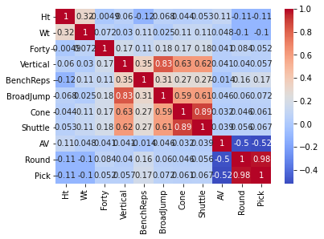

```python
import seaborn as sns
sns.heatmap(combine_LB.corr(), annot = True, cmap = 'coolwarm' )
```

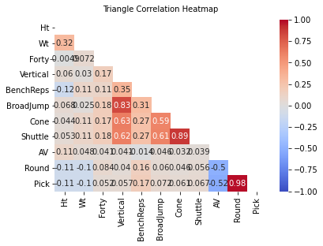

```python
mask = np.triu(np.ones_like(combine_LB.corr(), dtype=np.bool))
heatmap = sns.heatmap(combine_LB.corr(), mask=mask, vmin=-1, vmax=1, annot=True, cmap='coolwarm')
heatmap.set_title('Triangle Correlation Heatmap', fontdict={'fontsize':10}, pad=10)
```

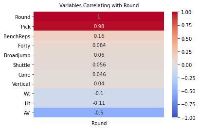

```python
heatmap = sns.heatmap(combine_LB.corr()[['Round']].sort_values(by='Round', ascending=False), vmin=-1, vmax=1, annot=True, cmap='coolwarm')
heatmap.set_title('Variables Correlating with Round', fontdict={'fontsize':10}, pad=10);
```

## Histogramas

En primer lugar, vamos a ver como se distribuyen los picks del draft en la posición de linebacker

```
count    375.000000
mean      86.594667
std       47.705827
min        2.000000
25%       45.500000
50%       87.000000
75%      126.500000
max      174.000000
Name: Pick, dtype: float64
```

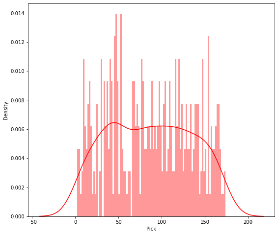

```python
print(combine_LB['Pick'].describe())
plt.figure(figsize=(9, 8))
sns.distplot(combine_LB['Pick'], color='r', bins=100, hist_kws={'alpha': 0.4});
```

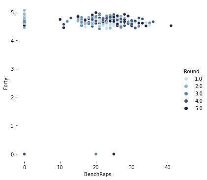

```python
cmap = sns.cubehelix_palette(rot=-.2, as_cmap=True)
g = sns.relplot(
    data=combine_LB,
    x="BenchReps", y="Forty", hue="Round",
    palette=cmap, sizes=(10, 200),
)
g.ax.xaxis.grid(True, "minor", linewidth=0.20)
g.ax.yaxis.grid(True, "minor", linewidth=0.20)
g.despine(left=True, bottom=True)
```

Vamos a probar ahora con dos variables muy correlacionadas entre si: BoardJump y Vertical

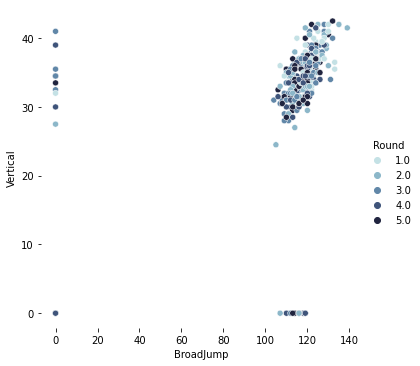

```python
cmap = sns.cubehelix_palette(rot=-.2, as_cmap=True)
g = sns.relplot(
    data=combine_LB,
    x="BroadJump", y="Vertical", hue="Round",
    palette=cmap, sizes=(10, 200),
)
g.ax.xaxis.grid(True, "minor", linewidth=0.20)
g.ax.yaxis.grid(True, "minor", linewidth=0.20)
g.despine(left=True, bottom=True)
```

Ahora vamos a estudiar como se distribuye el AV para cada Pick y Round

[output not shown]

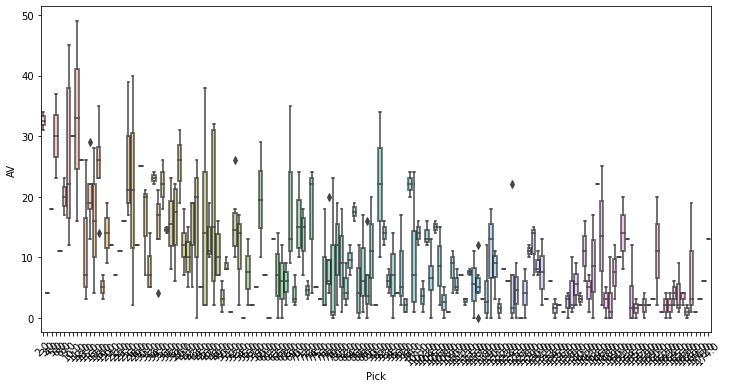

```python
plt.figure(figsize = (12, 6))
ax = sns.boxplot(x='Pick', y='AV', data=combine_LB)
plt.setp(ax.artists, alpha=.5, linewidth=2, edgecolor="k")
plt.xticks(rotation=45)
```

[output not shown]

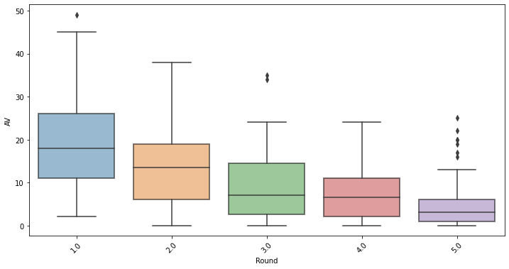

```python
plt.figure(figsize = (12, 6))
ax = sns.boxplot(x='Round', y='AV', data=combine_LB)
plt.setp(ax.artists, alpha=.5, linewidth=2, edgecolor="k")
plt.xticks(rotation=45)
```

Por último, representamos unos plots que indica la relación entre las variables de las variables y como se distribuyen

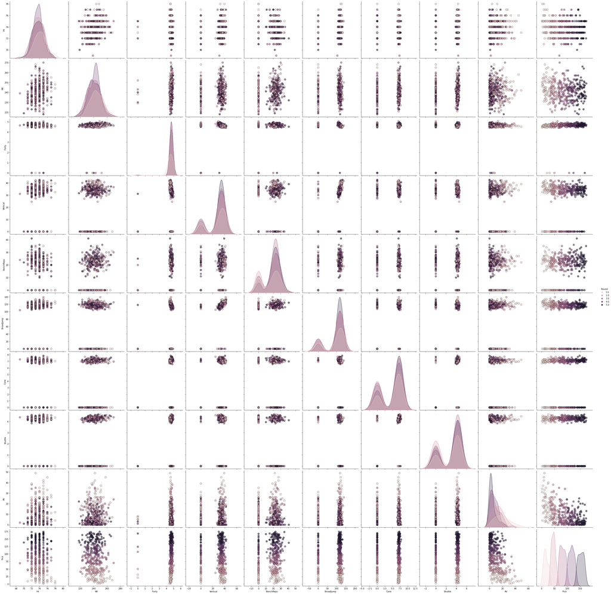

```python
sns.pairplot(combine_LB, hue = 'Round', diag_kind = 'kde',
             plot_kws = {'alpha': 0.6, 's': 80, 'edgecolor': 'k'},
             height = 4)
```

## Bibliografía

https://seaborn.pydata.org/tutorial/distributions.html

https://medium.com/@szabo.bibor/how-to-create-a-seaborn-correlation-heatmap-in-python-834c0686b88e

https://seaborn.pydata.org/index.html

https://towardsdatascience.com/exploratory-data-analysis-eda-python-87178e35b14